# Exercise 3

Yuting Huang, Jipeng Cheng, Weidi Hou

4/5/2022

# 1 Predictive model building: green certification

## 1.1 Overview

As landlords or renters, what they mostly care about is their possible revenue per square foot per calendar year. As we all know, leasing revenue depends on many factors, such as the building age, facilities, amenities, building size and so on. Nowadays, people pay more attention to their living environment when renting a house, such as whether the landlord has a green certification. Therefore, it’s meaningful to do some research on the relationship between rental income and green certification.

In our report, we build possibly the best predictive model for revenue per square foot per calendar year and to use this model to quantify the average change in rental income per square foot associated with green certification, holding other features of the building constant.

## 1.2 Data and research design

### 1.2.1 Data

In our raw data set, there are 7,820 data points. We first filter out the missing data. Now, our new `greenbuildings` data set has 7820 observations.

### 1.2.2 Predictive variable and features

The predictive variable is revenue per square foot per year, which is the product of two terms: rent and leasing_rate.

The features used to build our model are:

[output not shown]

## 1.3 Research design

Table 1.1: The RMSEs of Tree Models

| Random Forest | Boosting | KNN | LASSO |
| --- | --- | --- | --- |
| 732.1275 | 946.0623 | 980.1859 | 1059.02 |

We first split the new greenbuildings data set into training and test set, then we use four different tree methods: random forest, boosted regression trees, KNN regression and LASSO regression to build our model. Table 1.1 shows that random forest model is the best predictive model given out-of-sample accuracy. Therefore, we choose random forest model to identify the association between rental revenue and green certification.

## 1.4 Results

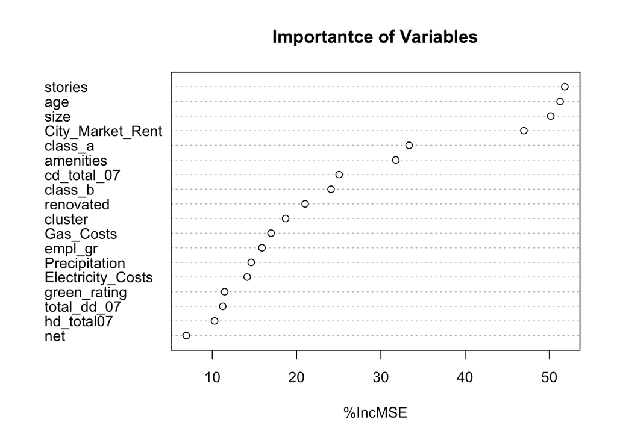

Figure 1.1: Figure of All Features Descending by Importance

From Figure 1.1, we found that the most important features that landlords should consider are `size`, `stories`, `age`. These variables contribute the most to the model. However, `green_rating` seems not very important.

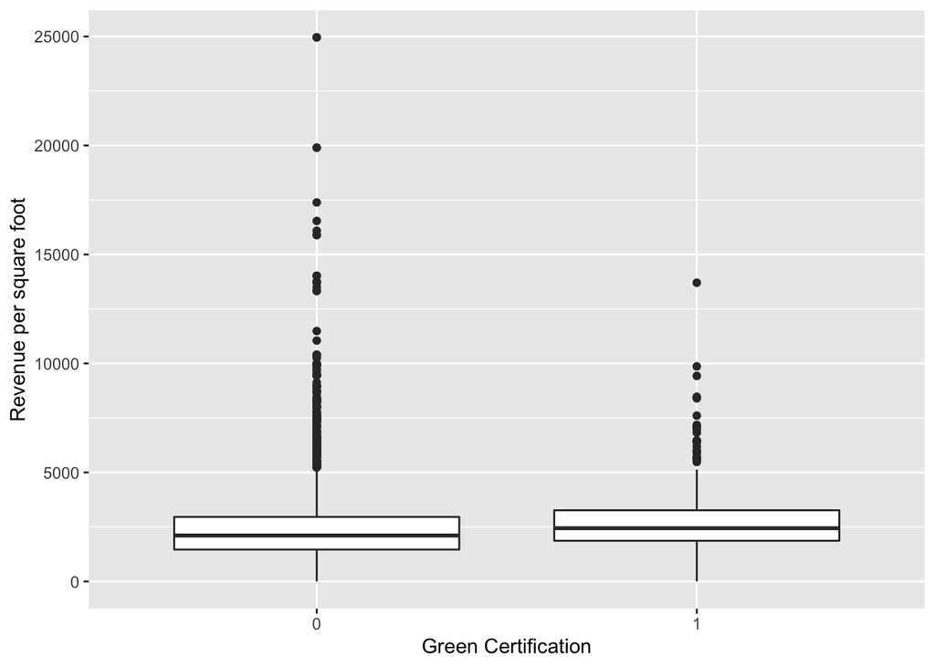

Figure 1.2: Impact of Green Certifications on Revenue

Figure 1.2 includes the information between revenue and green_rating, the average revenue per square foot is around $2693.526$ for buildings with a green certification, and around $2378.839$ for those without a certification. This shows that buildings with green certification get more revenue than those without green certification, but the impact is small.

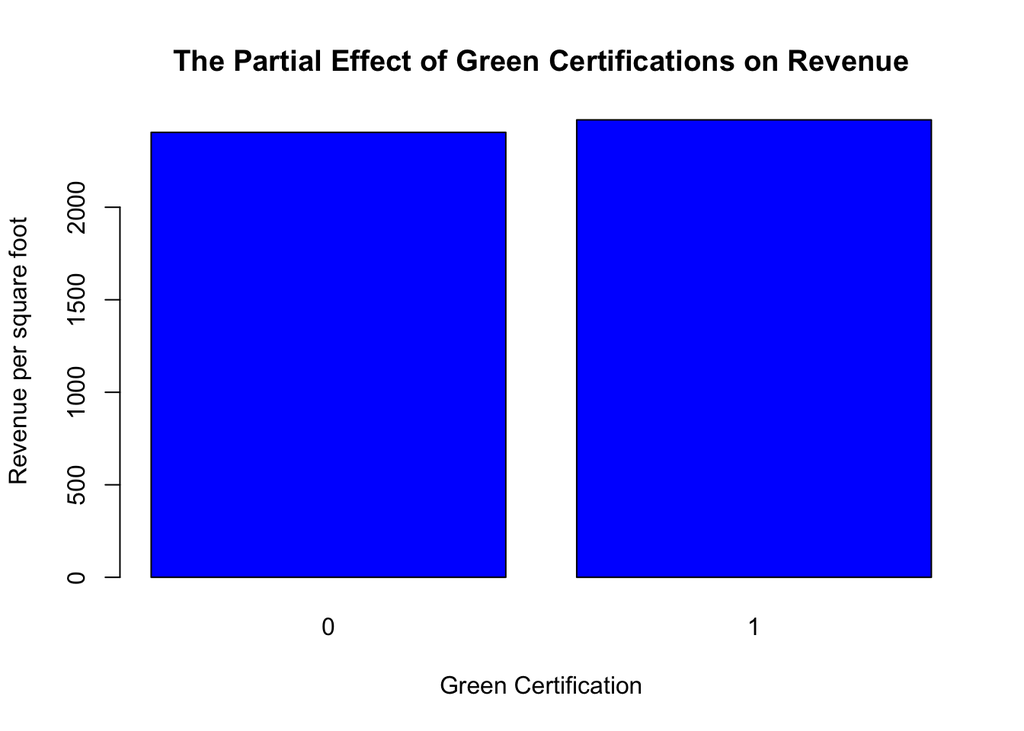

Figure 1.3: Partial Effect of Green Certifications on Revenue

From 1.3, we found a positive association between revenue and green certification, which means green certification is expected to increase revenue per square foot per year by $65.37967$ on average holding all else fixed.

## 1.5 Conclusion

From our analysis, we build a random forest model to estimate the association between green certification and revenue per square foot per year. By our results, we found that green certification has slightly positive impact on revenue. More specifically, green certification is associated with a $65.37967\$$ increase in revenue per square foot per year holding all else fixed. In addition, we found that `size`, `age`, `stories` have more impacts on revenue. Based on our research, the landlords should weigh the pros and cons of getting a green certification, thinking critically about the cost and revenue change of getting a green certification. If they think that the benefit doesn’t overweight the cost of getting a certification, they should focus on other features, which have more important impact on revenue.